# Linear Models: Multiple Continuous Predictors

## Problem

[figure not shown]

## Prediction

> Outcome: Juvenile Survival

Possible predictors:

- Birth date
- Birth mass
- Year
- Sex
- Maternal fecundity
- Maternal reproductive status
- Maternal age
- Population size
- Temperature (min, max, ave…)
- Rainfall
- Wind speed
- …

## Hierarchy of GLMs

[figure not shown]

## What is multiple regression *really* doing?

Determine the association of each predictor while “controlling” for the other predictors.

How?

- Allow the other variables to account for variation *in the predictor of interest*
  - Multiple regression of the predictor of interest on the remaining predictors (response variable not involved)
- Regress the response on the *residual* variance of the predictor of interest

## What is multiple regression *really* doing?

\[Y = \beta_0 + \beta_1 X_1 + \beta_2 X_2 + \beta_3 X_3 + \beta_4 X_4\]

To estimate the coefficient of \(X_1\):

- Regress \(X_1\) on \(X_2 + X_3 + X_4\)

\[X_1 = \gamma_0 + \gamma_1 X_2 + \gamma_2 X_3 + \gamma_3 X_4\]

- Calculate residuals for the model.
- Regress \(Y\) on the residuals.
- The estimated coefficient is \(\beta_1\).

## Residuals

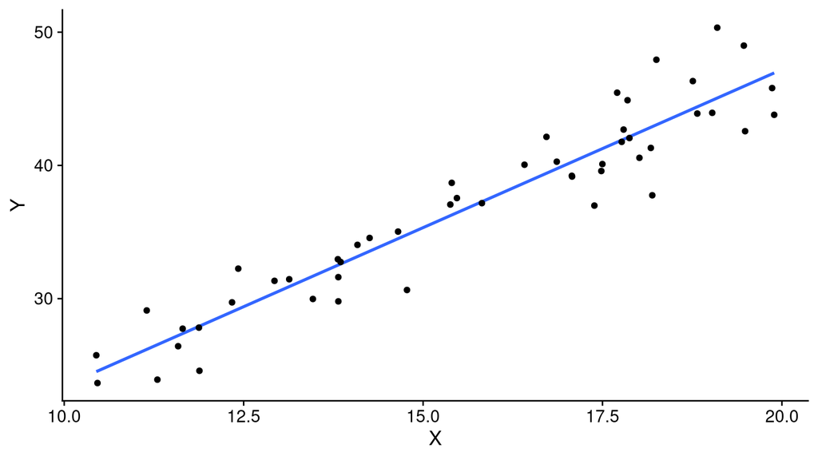

## Residuals

*Assumption*: Residuals from OLS regression should be centered on zero and normally distributed.

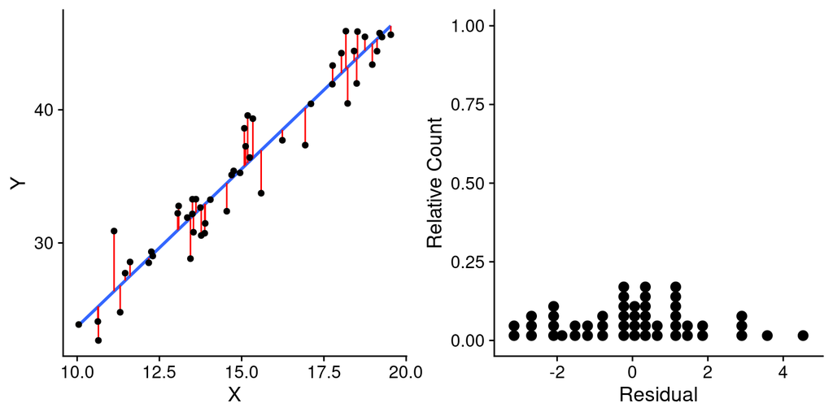

## Milk content across mammalian species

What are the contributions of the fat and lactose content of mammalian milk to total milk energy?

- *Outcome*: Kilocalories of energy per gram of milk
- *Predictors*:
  - Percent fat
  - Percent lactose

## Milk content across mammalian species

```r
milk <- read_excel("../data/Milk.xlsx", na = "NA")
glimpse(milk)
```

```
## Rows: 29
## Columns: 8
## $ clade          <chr> "Strepsirrhine", "Strepsirrhine", "Strepsirrhine", "St…
## $ species        <chr> "Eulemur fulvus", "E macaco", "E mongoz", "E rubrivent…
## $ kcal.per.g     <dbl> 0.49, 0.51, 0.46, 0.48, 0.60, 0.47, 0.56, 0.89, 0.91, …
## $ perc.fat       <dbl> 16.60, 19.27, 14.11, 14.91, 27.28, 21.22, 29.66, 53.41…
## $ perc.protein   <dbl> 15.42, 16.91, 16.85, 13.18, 19.50, 23.58, 23.46, 15.80…
## $ perc.lactose   <dbl> 67.98, 63.82, 69.04, 71.91, 53.22, 55.20, 46.88, 30.79…
## $ mass           <dbl> 1.95, 2.09, 2.51, 1.62, 2.19, 5.25, 5.37, 2.51, 0.71, …
## $ neocortex.perc <dbl> 55.16, NA, NA, NA, NA, 64.54, 64.54, 67.64, NA, 68.85,…
```

Ignore for now that these are comparative species-level data.

## Wrangling data

Keep:

- `species`: Species
- `kcal.per.g`: Kilocalories of energy per gram of milk
- `perc.fat`: Percent fat
- `perc.lactose`: Percent lactose

Filter complete cases (drop rows with `NA`).

```r
M <- milk %>% select(species, kcal.per.g, perc.fat, perc.lactose) %>%
  drop_na()
names(M) <- c("Species", "Milk_Energy", "Fat", "Lactose")
glimpse(M)
```

```
## Rows: 29
## Columns: 4
## $ Species     <chr> "Eulemur fulvus", "E macaco", "E mongoz", "E rubriventer"…
## $ Milk_Energy <dbl> 0.49, 0.51, 0.46, 0.48, 0.60, 0.47, 0.56, 0.89, 0.91, 0.9…
## $ Fat         <dbl> 16.60, 19.27, 14.11, 14.91, 27.28, 21.22, 29.66, 53.41, 4…
## $ Lactose     <dbl> 67.98, 63.82, 69.04, 71.91, 53.22, 55.20, 46.88, 30.79, 3…
```

## Visualizing data

[interactive chart not shown]

## Visualizing data

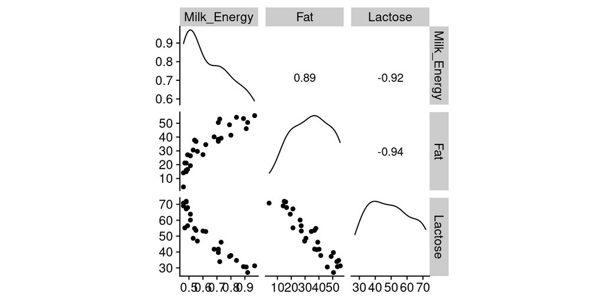

```r
library(GGally)
ggscatmat(M, columns = 2:4)
```

## Multiple regression

```r
fm <- lm(Milk_Energy ~ Fat + Lactose, data = M)
summary(fm)
```

```
##
## Call:
## lm(formula = Milk_Energy ~ Fat + Lactose, data = M)
##
## Residuals:
##      Min       1Q   Median       3Q      Max
## -0.11350 -0.05047  0.01103  0.04649  0.12701
##
## Coefficients:
##              Estimate Std. Error t value Pr(>|t|)
## (Intercept)  1.007372   0.211168   4.770 6.16e-05 ***
## Fat          0.001952   0.002533   0.771  0.44784
## Lactose     -0.008709   0.002575  -3.382  0.00229 **
## ---
## Signif. codes:  0 '***' 0.001 '**' 0.01 '*' 0.05 '.' 0.1 ' ' 1
##
## Residual standard error: 0.06447 on 26 degrees of freedom
## Multiple R-squared:  0.8518, Adjusted R-squared:  0.8404
## F-statistic: 74.74 on 2 and 26 DF,  p-value: 1.657e-11
```

## Visualizing multiple regression

[interactive chart not shown]

## Estimate `Fat` coefficient

1. Use `Lactose` to predict `Fat`, which will take the effect of `Lactose` out of the model when we predict `Milk_Energy`
2. Extract the residuals and add them onto the data.

```r
fm_Lact <- lm(Fat ~ Lactose, data = M)
M$resid_Lact <- residuals(fm_Lact)
head(M)
```

```
## # A tibble: 6 x 5
##   Species            Milk_Energy   Fat Lactose resid_Lact
##   <chr>                    <dbl> <dbl>   <dbl>      <dbl>
## 1 Eulemur fulvus            0.49  16.6    68.0      0.196
## 2 E macaco                  0.51  19.3    63.8     -1.12
## 3 E mongoz                  0.46  14.1    69.0     -1.28
## 4 E rubriventer             0.48  14.9    71.9      2.27
## 5 Lemur catta               0.6   27.3    53.2     -3.25
## 6 Alouatta seniculus        0.47  21.2    55.2     -7.42
```

## Estimate `Fat` coefficient

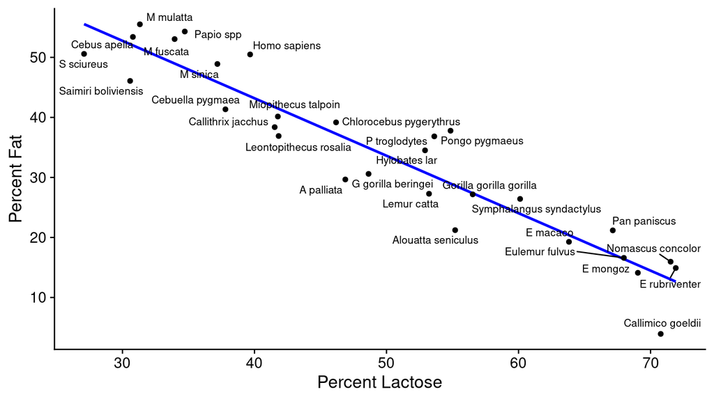

## Estimate `Fat` coefficient

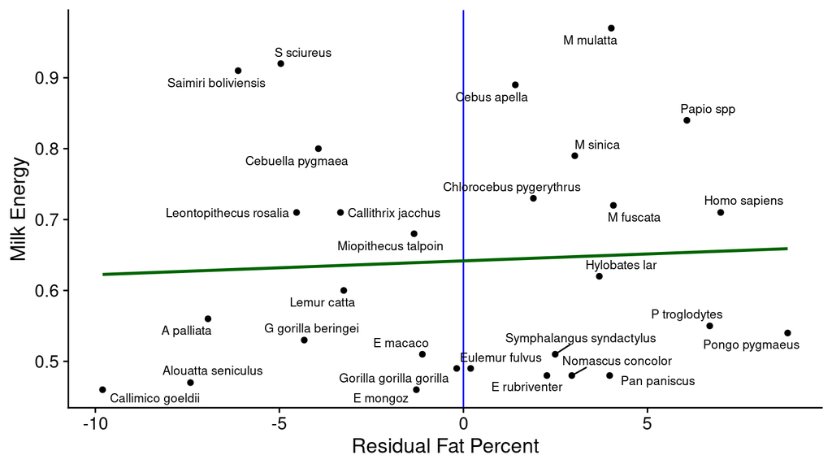

## Estimate `Fat` coefficient

```r
coef(lm(Milk_Energy ~ resid_Lact, data = M))
```

```
## (Intercept)  resid_Lact
## 0.641724138 0.001952441
```

```r
coef(fm)
```

```
##  (Intercept)          Fat      Lactose
##  1.007371840  0.001952441 -0.008708827
```

## Estimate `Lactose` coefficient

1. Use `Fat` to predict `Lactose`, which will take the effect of `Fat` out of the model when we predict `Milk_Energy`
2. Extract the residuals and add them onto the data.frame `M`.

```r
fm_Fat <- lm(Lactose ~ Fat, data = M)
M$resid_Fat <- residuals(fm_Fat)
```

## Estimate `Lactose` coefficient

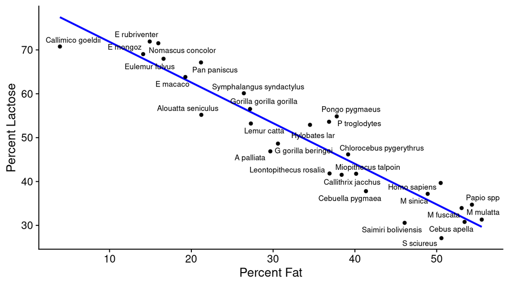

## Estimate `Lactose` coefficient

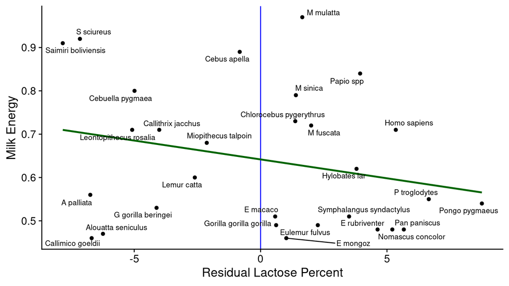

## Estimate `Lactose` coefficient

```r
coef(lm(Milk_Energy ~ resid_Fat, data = M))
```

```
##  (Intercept)    resid_Fat
##  0.641724138 -0.008708827
```

```r
coef(fm)
```

```
##  (Intercept)          Fat      Lactose
##  1.007371840  0.001952441 -0.008708827
```

## Compare

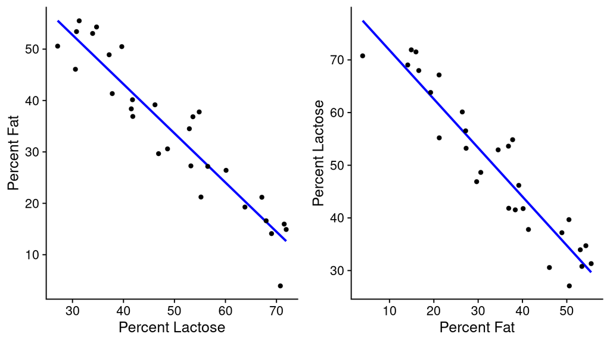

## Compare

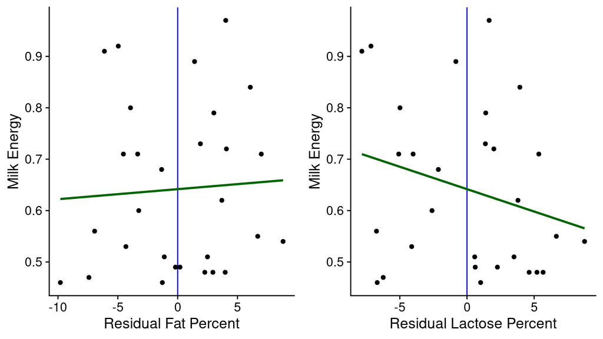

## Multicollinearity

High correlation between predictors leaves little residual variation to be used for explaining the outcome variable.

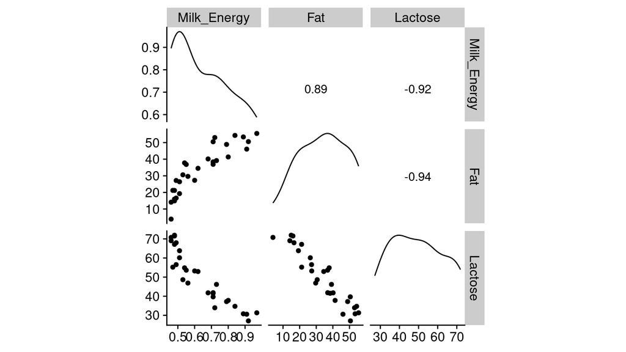

## Masking

Multiple predictors are useful for predicting outcomes when bivariate relationships with the response variable is not strong.

But:

- Associative relationships can be obscured when two predictors are somewhat correlated with one another.

## Mammal milk data in a different context

Milk is a big energetic investment

- Is there a significant association between energy content of milk while controlling for neocortex size and body size?
- Do primates with larger brains produce significantly more nutritious milk so their offspring can grow quickly (because they must grow quickly) ?

## Visualizing

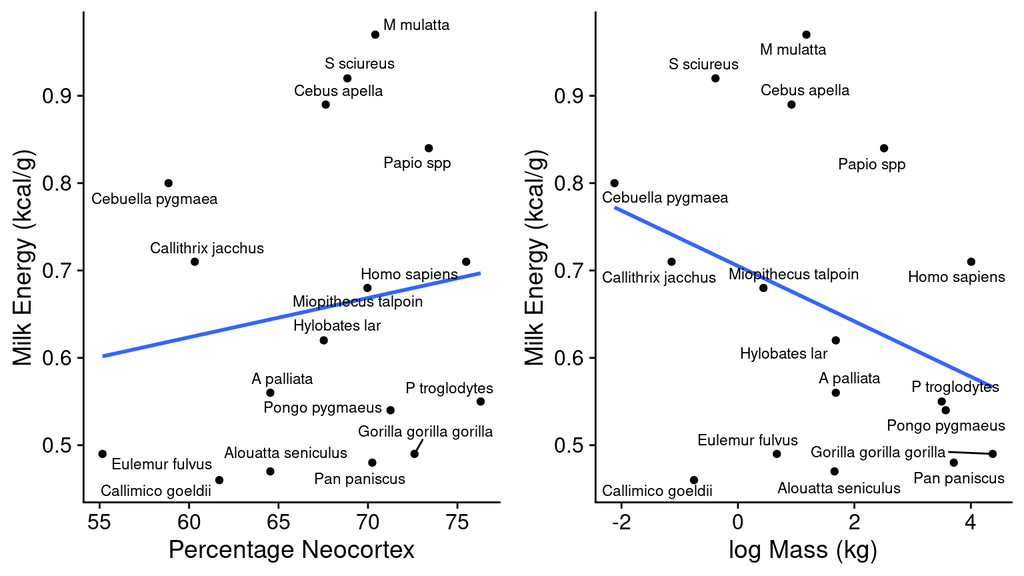

## Visualizing

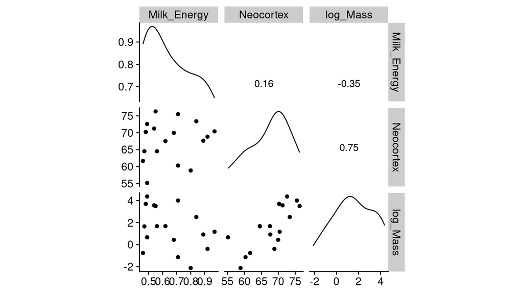

## Bivariate model of Neocortex

```r
fm_Neo <- lm(Milk_Energy ~ Neocortex, data = M)
summary(fm_Neo)
```

```
##
## Call:
## lm(formula = Milk_Energy ~ Neocortex, data = M)
##
## Residuals:
##      Min       1Q   Median       3Q      Max
## -0.19027 -0.14693 -0.03744  0.15613  0.29959
##
## Coefficients:
##             Estimate Std. Error t value Pr(>|t|)
## (Intercept) 0.353332   0.501120   0.705    0.492
## Neocortex   0.004503   0.007389   0.609    0.551
##
## Residual standard error: 0.1764 on 15 degrees of freedom
## Multiple R-squared:  0.02417,    Adjusted R-squared:  -0.04089
## F-statistic: 0.3715 on 1 and 15 DF,  p-value: 0.5513
```

## Bivariate model of log Mass

```r
fm_Mass <- lm(Milk_Energy ~ log_Mass, data = M)
summary(fm_Mass)
```

```
##
## Call:
## lm(formula = Milk_Energy ~ log_Mass, data = M)
##
## Residuals:
##      Min       1Q   Median       3Q      Max
## -0.26908 -0.09190 -0.03189  0.13180  0.30209
##
## Coefficients:
##             Estimate Std. Error t value Pr(>|t|)
## (Intercept)  0.70516    0.05185  13.599 7.68e-10 ***
## log_Mass    -0.03169    0.02160  -1.467    0.163
## ---
## Signif. codes:  0 '***' 0.001 '**' 0.01 '*' 0.05 '.' 0.1 ' ' 1
##
## Residual standard error: 0.167 on 15 degrees of freedom
## Multiple R-squared:  0.1255, Adjusted R-squared:  0.0672
## F-statistic: 2.153 on 1 and 15 DF,  p-value: 0.163
```

## Multivariate model

```r
fm_Multi <- lm(Milk_Energy ~ Neocortex + log_Mass, data = M)
summary(fm_Multi)
```

```
##
## Call:
## lm(formula = Milk_Energy ~ Neocortex + log_Mass, data = M)
##
## Residuals:
##       Min        1Q    Median        3Q       Max
## -0.250574 -0.039212  0.000633  0.072997  0.201985
##
## Coefficients:
##              Estimate Std. Error t value Pr(>|t|)
## (Intercept) -1.085254   0.515281  -2.106  0.05372 .
## Neocortex    0.027931   0.008015   3.485  0.00364 **
## log_Mass    -0.096402   0.024749  -3.895  0.00162 **
## ---
## Signif. codes:  0 '***' 0.001 '**' 0.01 '*' 0.05 '.' 0.1 ' ' 1
##
## Residual standard error: 0.1265 on 14 degrees of freedom
## Multiple R-squared:  0.5317, Adjusted R-squared:  0.4648
## F-statistic: 7.948 on 2 and 14 DF,  p-value: 0.004939
```

## Interpretation

Regression asks (and answers):

1. Do species that have high neocortex percentage *for their mass* have higher energy milk?
2. Do species with high body mass *for their neocortex percentage* have higher energy milk?

## Neocortex vs. log Mass

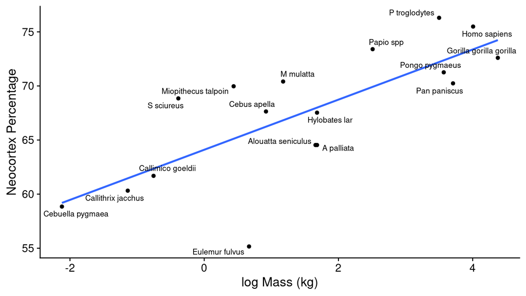

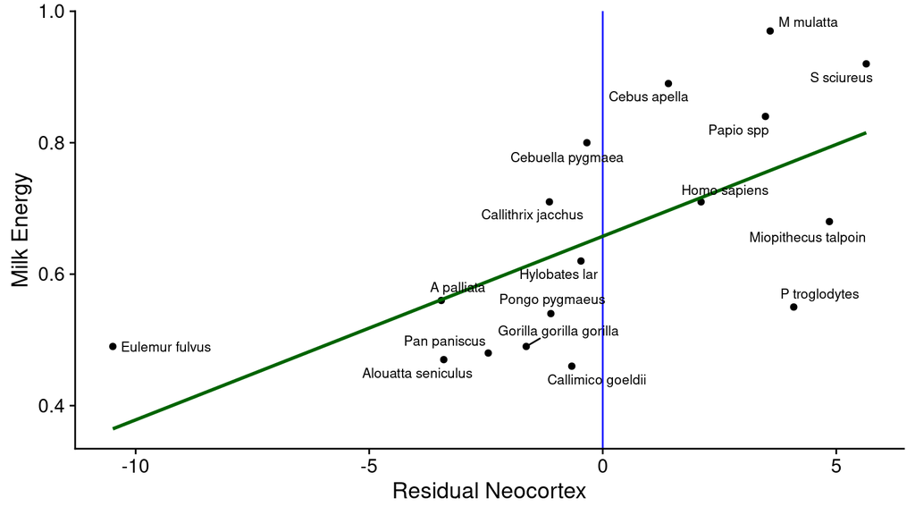